# ¡Nos vamos a Noruega!

Autores/as

Gema Fernández-Avilés (Gema.FAviles@uclm.es)

Isidro Hidalgo (Isidro.Hidalgo@uclm.es)

Fecha de publicación

16 de enero de 2025

**Nota**

Los datos que se utilizan en esta historia están disponibles en el repositorio GitHub “From data to viz”: https://github.com/holtzy/data_to_viz.

# 1 ¡Nos vamos a Noruega!

Mi jefe quiere que le haga un análisis exploratorio (eso dice, pero siempre quiere gráficos guays con conclusiones interesantes…) de unos datos demográficos por países. Lo peor es que quiere que le acompañe a Noruega, que hay un workshop “fantástico” [sic]…

Con el frío que hace ahora en Noruega… Pero este hombre, ¿por qué no elige estas cosas con más criterio y nos vamos a Hawai? ¡Por ejemplo!

# 2 Entender el contexto

**Cómo definir el propósito y la audiencia de tu análisis**

En este caso, puesto que lo que me pide el jefe es un análisis exploratorio, se trata simplemente de encontrar relaciones interesantes entre variables, mirar su evolución, por si se ven cosas interesantes, y preparar gráficos que vayan al grano, como ya sabemos hacer… ¡Que para algo sirven los cursos de la UCLM!

**Lectura de paquetes necesarios**

```r
library(tidyverse)
library(GGally)
library(NbClust)
library(igraph)
library(factoextra)
library(corrplot)
library(explore)
```

**Lectura de datos formato `csv` en local desde la carpeta `data`**

```r
demog_data <- read.table("data/multivariate.csv", header = T, sep = ";")
```

**Lectura de datos formato `csv` directamente desde la web**

```r
demog_data <- read.table("https://raw.githubusercontent.com/holtzy/data_to_viz/master/Example_dataset/multivariate.csv", header = T, sep = ";")
```

**Estilo de código. Cambio los puntos por guiones**

```r
colnames(demog_data) <- gsub("\\.", "_", colnames(demog_data))
colnames(demog_data)
```

```
 [1] "Country"             "Pop"                 "Birth_rate"
 [4] "Mortality_rate"      "Life_expectancy"     "Infant_mortality"
 [7] "Children_per_woman"  "Growth_rate"         "Population_aged_65_"
[10] "Group"               "Continent"
```

**Renombra la 9 variable eliminando el último guión**

```r
names(demog_data)[9] <- "Population_aged_65"
```

**Primera vista de los datos**

```r
head(demog_data, 3)
```

```
          Country  Pop Birth_rate Mortality_rate Life_expectancy
1 Channel Islands  166      9.280          9.140          81.269
2         Denmark 5733     10.707          9.620          80.839
3         Estonia 1302     10.698         12.657          77.342
  Infant_mortality Children_per_woman Growth_rate Population_aged_65 Group
1            7.276              1.492        4.56                 30 North
2            3.495              1.758        3.67               1132 North
3            2.843              1.657       -2.63                256 North
  Continent
1    Europe
2    Europe
3    Europe
```

**Tu turno**

Completa las partes del código señaladas por `_____` o `xxxxx` para obtener el resultado propuesto. ¿Te acuerdas de las funciones para explorar todas las variables a la vez?

**Exploración básica**

```r
demog_data |> xxxxxxx_all()
```

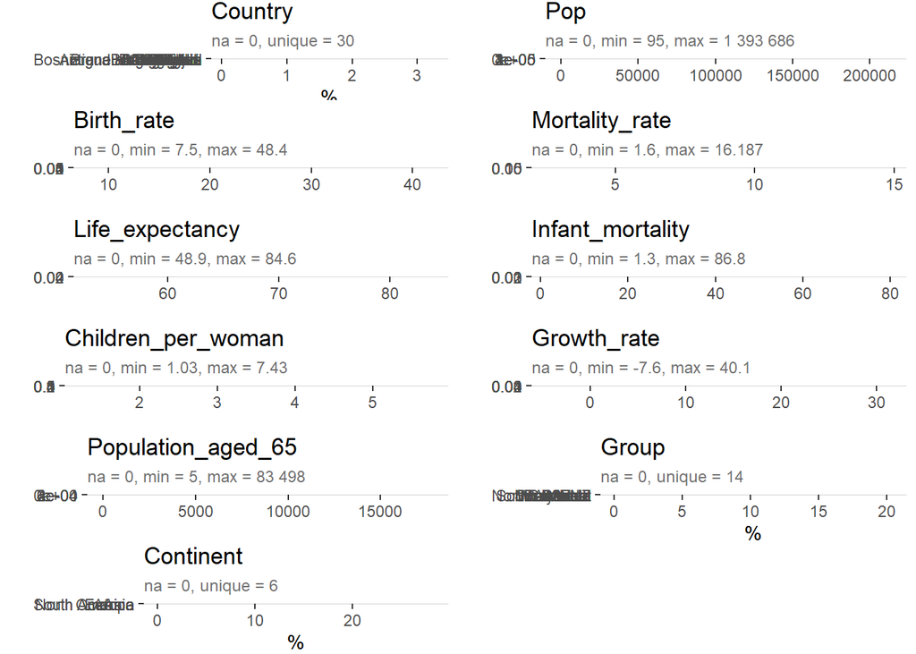

```
   Country               Pop            Birth_rate    Mortality_rate
 Length:201         Min.   :     95   Min.   : 7.50   Min.   : 1.600
 Class :character   1st Qu.:   1198   1st Qu.:11.90   1st Qu.: 6.000
 Mode  :character   Median :   6213   Median :17.70   Median : 7.500
                    Mean   :  36411   Mean   :20.13   Mean   : 7.874
                    3rd Qu.:  22445   3rd Qu.:27.50   3rd Qu.: 9.400
                    Max.   :1393686   Max.   :48.40   Max.   :16.187
 Life_expectancy Infant_mortality Children_per_woman  Growth_rate
 Min.   :48.90   Min.   : 1.30    Min.   :1.03       Min.   :-7.60
 1st Qu.:66.80   1st Qu.: 5.50    1st Qu.:1.75       1st Qu.: 3.70
 Median :74.40   Median :14.50    Median :2.17       Median :11.10
 Mean   :72.39   Mean   :22.53    Mean   :2.67       Mean   :12.03
 3rd Qu.:78.30   3rd Qu.:36.20    3rd Qu.:3.56       3rd Qu.:20.30
 Max.   :84.60   Max.   :86.80    Max.   :7.43       Max.   :40.10
 Population_aged_65    Group            Continent
 Min.   :    5      Length:201         Length:201
 1st Qu.:   93      Class :character   Class :character
 Median :  464      Mode  :character   Mode  :character
 Mean   : 2370
 3rd Qu.: 1493
 Max.   :83498
```

**Código**

```r
xxxxxxx(demog_data)
```

# 3 Elegir una visualización adecuada

**Selección de gráficos y visualizaciones que mejor representen tus datos.**

## 3.1 Matriz diagramas de dispersión (*scatterplot matrix*)

Podemos comenzar por una matriz de puntos de las variables cuantitativas. El paquete `GGally` ofrece una visualización muy elaborada para un primer vistazo con la función `ggpairs()`…

**Cuidado: solo variables cuantitativas.**

**Selecciona las variables cuantitativas**

```r
demo_cuanti <- demog_data |>
   select(Pop, Birth_rate, Mortality_rate, Life_expectancy,
          Infant_mortality, Children_per_woman,  Growth_rate,
          Population_aged_65) |>
   na.omit()
```

**Matriz de correlaciones y diagramas de dispersión**

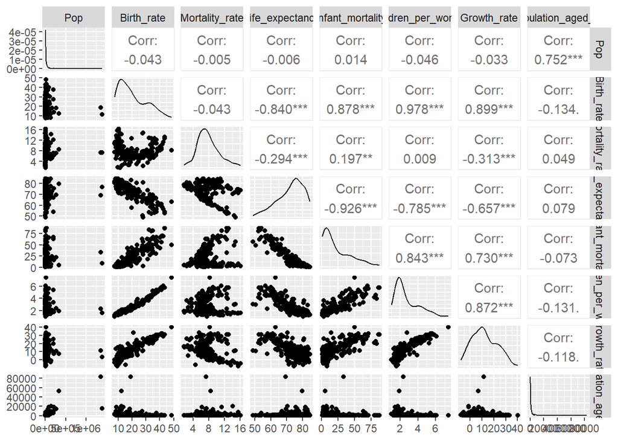

```r
demo_cuanti |>
   ggpairs(progress = FALSE)
```

Hay muchas asociaciones interesantes entre diferentes variables. Aquí ya vemos mucha tela que cortar. Por no extendernos, analizaremos una de las relaciones más adelante. Pero primero, es muy interesante ver la matriz de correlaciones que, aunque con `ggpairs()` teníamos ya una primera impresión, el paquete `corrplot` nos ofrece una visualización ideal con la función `corrplot.mixed()`:

## 3.2 Matriz de correlaciones

**Matriz de correlaciones**

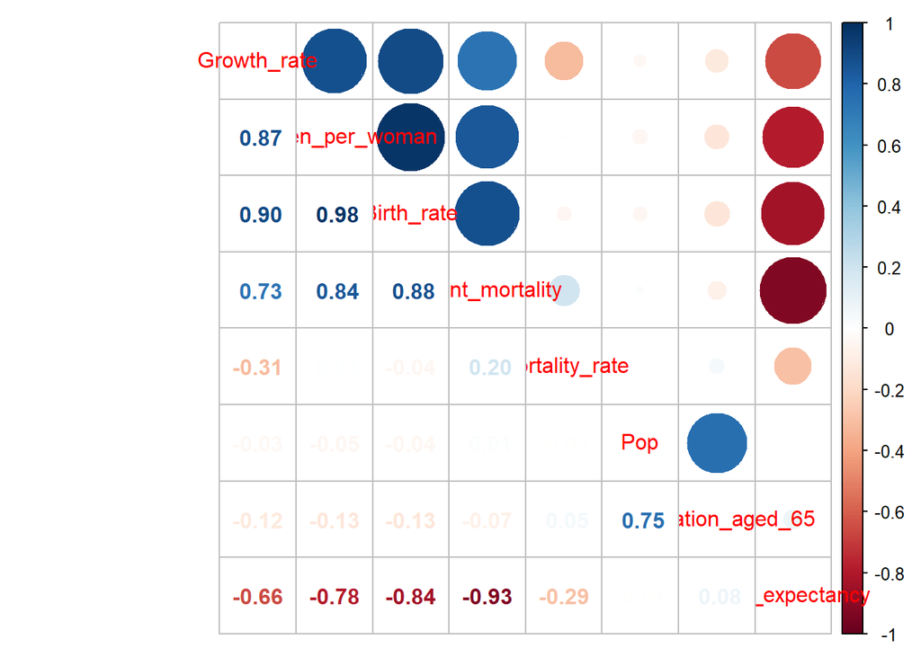

```r
demo_cuanti |>
  cor() |>
  corrplot.mixed( order = 'AOE')
```

## 3.3 Gráfico de puntos entre o scatterplot `Growth_rate` y `Life_expectancy`

Como ejemplo, vamos a ver la relación entre la esperanza de vida y la tasa de crecimiento, que ya hemos visto que existe. Empecemos con un gráfico de puntos…

**Tu turno**

Completa las partes del código señaladas por `_____` o `xxxxx` para obtener el resultado propuesto. ¿Te acuerdas de la función de `ggplot2` para una capa de puntos?

**Diagrama de dispersión**

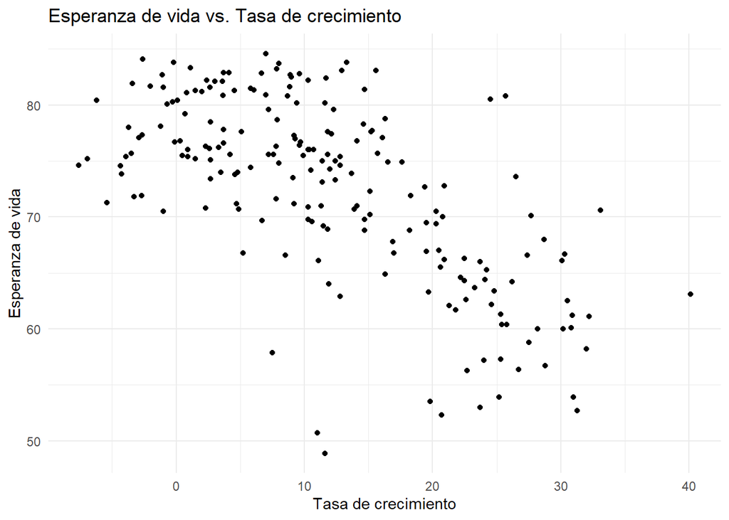

```r
demog_data  |>
  ggplot(aes(x = Growth_rate, y = Life_expectancy)) +
  geom_xxxxx) +
  labs(title = "Esperanza de vida vs. Tasa de crecimiento",
       x = "Tasa de crecimiento",
       y = "Esperanza de vida") +
  theme_minimal()
```

**Hexbin plot**

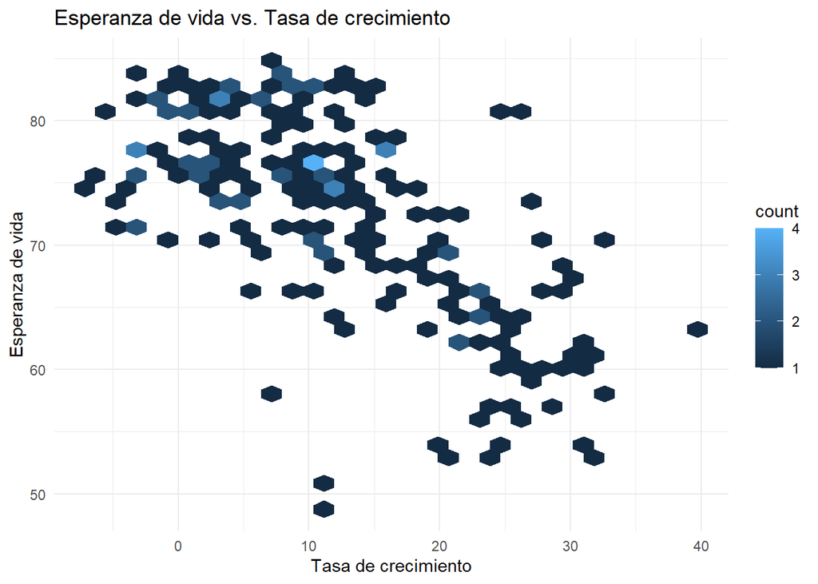

```r
demog_data  |>
  ggplot(aes(x = Growth_rate, y = Life_expectancy)) +
  geom_hex() +
  labs(title = "Esperanza de vida vs. Tasa de crecimiento",
       x = "Tasa de crecimiento",
       y = "Esperanza de vida") +
  theme_minimal()
```

# 4 Eliminar el desorden. Enfocar la atención

¿Qué herramientas tenemos a nuestro alcance para poner el foco sobre lo que nos interesa? Aquí podemos usar la estética y las facetas, para separar los puntos y dar más información a través de la visualización. Veamos…

## 4.1 Herramienta 1: la estética

**Diagrama de dispersión mejorado por estética**

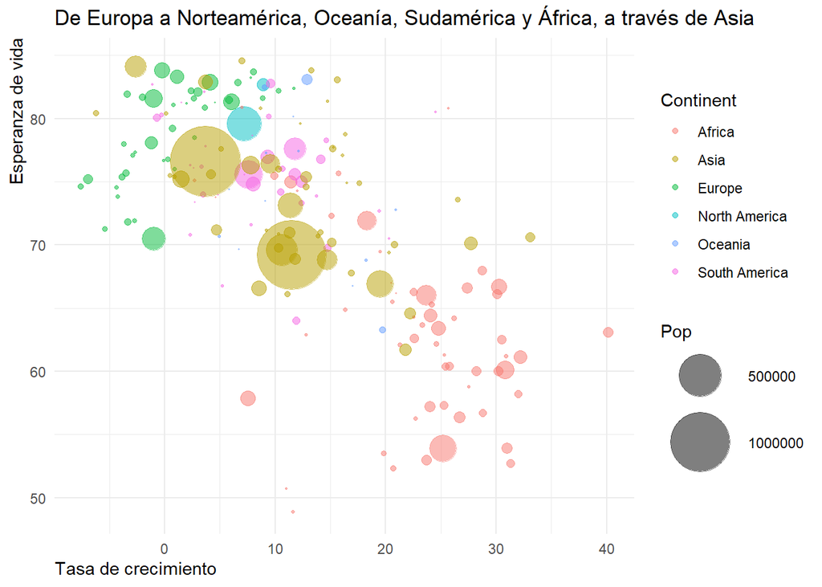

```r
demog_data  |>
  ggplot(aes(x = Growth_rate, y = Life_expectancy, size = Pop,
             color = Continent)) +
  geom_point(alpha=0.5) +
  scale_size(range = c(.1, 20)) +
  labs(title = "De Europa a Norteamérica, Oceanía, Sudamérica y África, a través de Asia",
       x = "Tasa de crecimiento",
       y = "Esperanza de vida") +
  theme_minimal() +
  theme(axis.title.x = element_text(hjust = 0),
        axis.title.y = element_text(hjust = 1))
```

También somos capaces de identificar China e India rápidamente, por su tamaño, y Japón arriba a la izquierda por su tamaño medio-grande y enorme esperanza de vida.

Sin embargo, hay colores muy parecidos, que exigen demasiada atención. Podemos usar la siguiente herramienta…

## 4.2 Herramienta 2: facetas

Otra forma de eliminar el desorden y enfocar la atención es usar facetas, separando el gráfico según una o más variables interesantes. En este caso usamos solo el continente:

**Diagrama de dispersión mejorado por facetas**

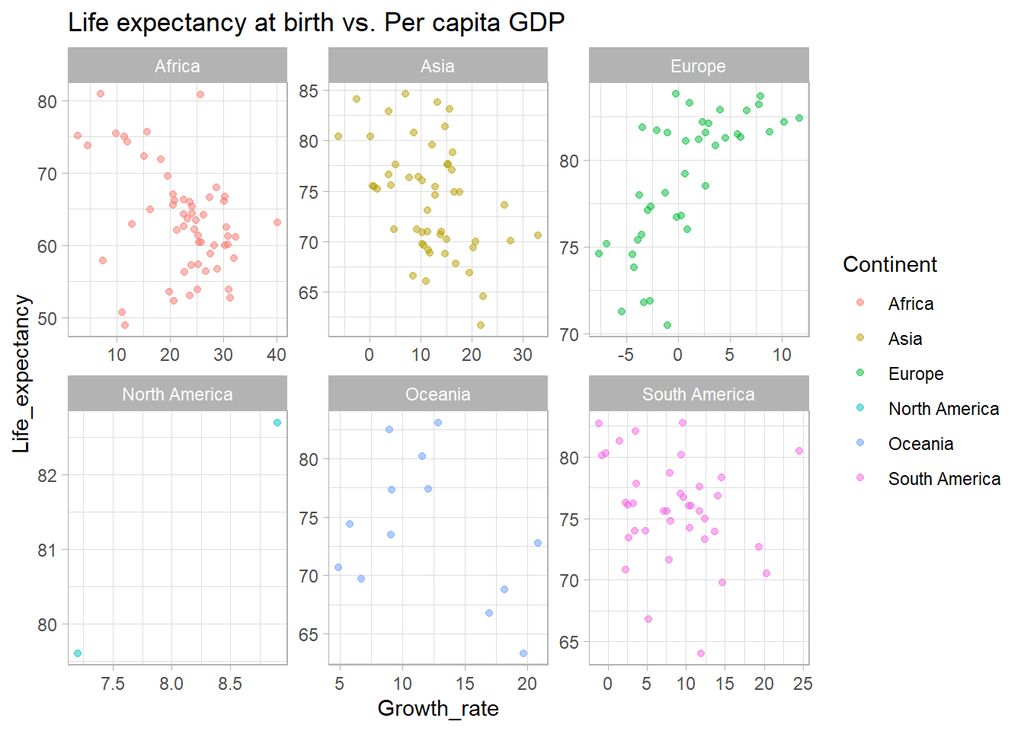

```r
demog_scatter <- ggplot(data = demog_data, # data
              aes(x = Growth_rate, y = Life_expectancy, colour = Continent)) + #aesthetics
    geom_point(alpha = 0.5) + #geometries
    facet_wrap(~ Continent, scales = "free") + #facets
    labs(title = "Life expectancy at birth vs. Per capita GDP",
         x = "Growth_rate", y = "Life_expectancy", colour = "Continent") + #labels
    theme_light() #themes

demog_scatter
```

**Ejercicio 1** ¿Qué problema podría tener este gráfico?

**Pista**

¡fijaos en los ejes!

Exacto: las escalas. Pero hemos dicho “podría”, no que tenga un problema en sí. Cuando nuestra intención es mirar dentro de cada faceta para ver la relación entre las variables, es posible que nos interese dejarlo como está.

Pero muchas veces es muy importante, cuando usamos facetas, que podamos comparar los diferentes grupos entre sí. En este caso, es imprescindible usar la misma escala en todas las facetas. Para ello, hay que especificar los límites de las escalas de los ejes.

¿Existe una forma fácil de saber cuáles poner? Claro, con un `summary()` de las variables, tal como indicamos a continuación, vemos rápidamente el valor mínimo y máximo de las variables que nos interesan:

**Mejoramos la escala para comparar facetas**

```r
summary(demog_data$Life_expectancy)
```

```
   Min. 1st Qu.  Median    Mean 3rd Qu.    Max.
  48.90   66.80   74.40   72.39   78.30   84.60
```

**Mejoramos la escala para comparar facetas**

```r
summary(demog_data$Growth_rate)
```

```
   Min. 1st Qu.  Median    Mean 3rd Qu.    Max.
  -7.60    3.70   11.10   12.03   20.30   40.10
```

**Mejoramos la escala para comparar facetas**

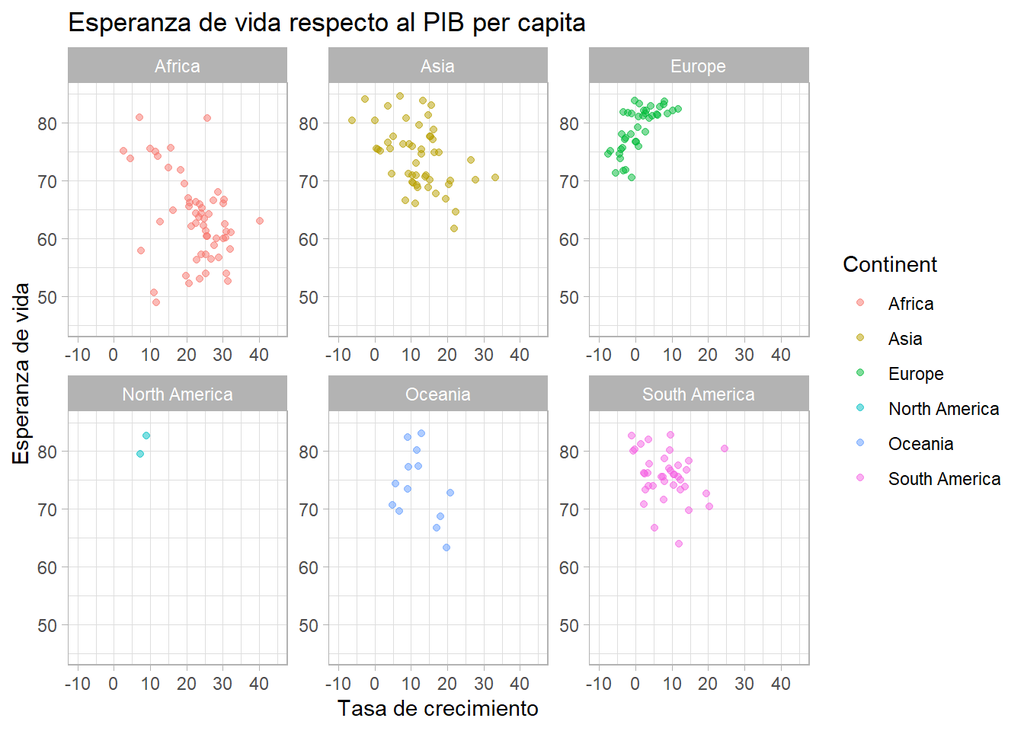

```r
demog_scatter_escala <- ggplot(data = demog_data,
                               aes(x = Growth_rate,
                                   y = Life_expectancy,
                                   colour = Continent)) +
  geom_point(alpha = 0.5) +
  facet_wrap(~ Continent, scales = "free") +
  labs(title = "Esperanza de vida respecto al PIB per capita",
       x = "Tasa de crecimiento", y = "Esperanza de vida",
       colour = "Continent") +
  scale_x_continuous(limits = c(-10, 45)) +
  scale_y_continuous(limits = c(45, 85)) +
  theme_light()

demog_scatter_escala
```

## 4.3 Linea de suavizado

**Tu turno**

Completa las partes del código señaladas por `_____` o `xxxxx` para obtener el resultado propuesto. ¿Qué objeto tienes que incluir sobre el que añadir la línea de tendencia?

**Añadimos línea de suavizado**

```r
______ + geom_smooth(method = NULL, se = TRUE)
```

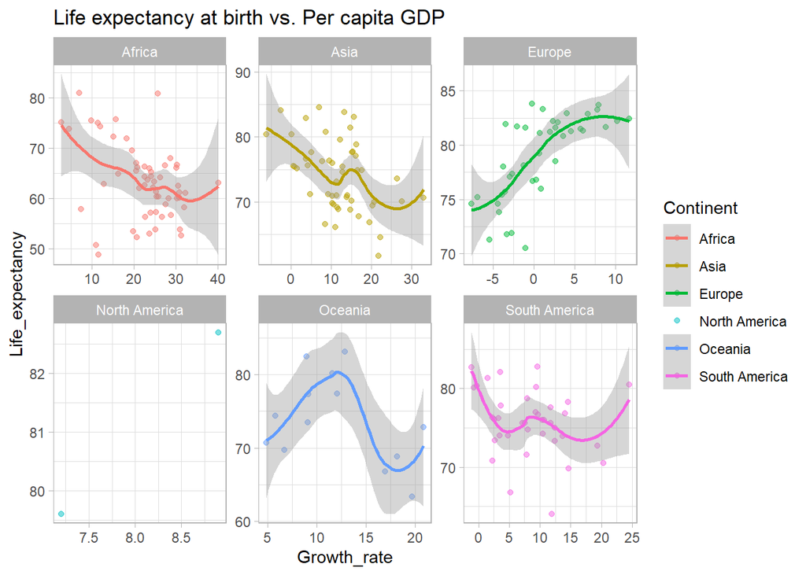

# 5 Contar una historia

**Cómo narrar una historia convincente con tus datos.**

Hemos visto el **planteamiento**, en el que proporcionamos el contexto: trabajamos para un jefe que nos ha pedido algo muy concreto: un análisis exploratorio (y sabemos que lo quiere con conclusiones)…

El análisis exploratorio podemos usarlo para ir introduciendo la **trama**, donde vemos enseguida relaciones interesantes entre algunas parejas de variables… Solo hemos analizado la esperanza de vida al nacer respecto a la tasa de crecimiento, pero en la matriz de puntos hemos visto muchas, por lo que el jefe estará feliz.

Como siempre, lo más importante es el **desenlace**, donde le estamos dando a nuestro jefe las claves que necesita:

- La matriz de puntos es vital, si nuestro superior está habituado al análisis, porque **se aprecia un número importante de relaciones claras entre variables**.
- En cada variable **podemos usar la estética y las facetas para potenciar la visualización**, determinando las variables que suministran información en las relaciones encontradas.

Finalmente, hemos visto que, cuando tenemos un número elevado de información, tenemos que adoptar una decisión equilibrada entre la información que suministramos en nuestros gráficos y nuestra habilidad para eliminar el desorden y enfocar la mirada del espectador a lo que nos interesa más. Para el caso que nos ocupa, podemos:

- Usar la agrupación previa por zonas geográficas, como hemos hecho antes.
- Restringir la visualización a una zona geográfica concreta.
- Filtrar determinados países para quedarnos con los que nos interesa comparar.
- Directamente usar una tabla, relacionando todos los países de interés.

# 6 Para pensar:

A veces no tenemos más remedio que proporcionar una visualización con mucha información, si ésta es clave para nuestro propósito.